# Lecture 12

## Speech Recognition

### cscie-89 Deep Learning

- Learning Objectives
  - Sound into numbers
- Visualization of the recordings - input features
  - Wave and spectrogram
  - MFCC
  - Silence removal
  - Resampling - dimensionality reductions
  - Features extraction steps
- Dataset investigation
  - Number of files
  - Mean spectrograms and fft
  - Deeper into recordings
  - Length of recordings
  - Note on Gaussian Mixtures modeling
  - Frequency components across the words
  - Anomaly detection
- Where to look for inspiration

## Learning Objectives

Towards the end of the lecture we wil build a Simple Speech Recognition Engine using Convolutional Layers in Keras which will classified different sounds.  
- We will learn how to perform feature extraction (MFCC) and train the model  
- We will demonstrate that our model can recognize words.  
- Determine different words captured by the microphone (Test)

We learned about CNNs, RNNs and classified MNIST for images dataset using Deep Learning libraries. We learned how to take an image and treat it as an array of numbers so that we can feed directly into a neural network for image recognition and now we can do the same with speech recognition audio files!

### Sound is transmitted as waves. How do we turn sound waves into numbers?

Speech recognition is complex and tricky so to keep everything simple we will start with a practical tutorial using word recognition and Kaggle datasets of number words.

### Data and Code

Data used in the examples in this notebook are downloaded from https://storage.cloud.google.com/download.tensorflow.org/data/speech_commands_v0.02.tar.gz site. The directory into which we expanded collections of single spoken words: bird, dog, cat, four, happy,..., etc, we called `data`.  
To reduce the processing time, we trained the neural network using a subset of data. You can do as you please. You can work with small or the entire data set.  
Static images in this notebook should resided in directory named `images`. The content of the directory `images` is provide on the class site, week 12 folder.  
Code used in the examples below is borrowed from: https://blog.manash.me/building-a-dead-simple-word-recognition-engine-using-convnet-in-keras-25e72c19c12b

Speech recordings are broken up into little chunks of phonetic signals of typical duration of 25 msec. Those windows are overlapping and slide (typically) 10 msec at a time.  
The distinguishable units of speech are called phoneme.  
Phoneme units are grouped into words  
Spoken words are a sequence of sound waves  
We will create vectors from the audio signal in order to feed our deep learning model. We work with RNN (LSTM)s to processes sequences.  
In the follwing examples we will actually use convolutional neural networks for the classification of speech samples.  
Inputs will be tensors of features representing speech utterances.

[figure not shown]

We will perform classification using audio files with small words such as "seven", "happy", "yes", others

### How to embed the audio into vector space?

There are many techniques and some Python packages solely for extraction of audio features.  
MFCC encoding (Mel Frequency Cepstral Coefficients) is a very effective technique for encoding of speech signals. That technique was used for classicla non-nural network speech recognition.

# Various libraries we might or might not use

```python
import os
from os.path import isdir, join
from pathlib import Path
import pandas as pd

# Math
import numpy as np
from scipy.fftpack import fft
from scipy import signal
from scipy.io import wavfile
import librosa

from sklearn.decomposition import PCA

# Visualization
import matplotlib.pyplot as plt
import seaborn as sns
import IPython.display as ipd
import librosa.display

import plotly.offline as py
py.init_notebook_mode(connected=True)
import plotly.graph_objs as go
import plotly.tools as tls
import pandas as pd

%matplotlib inline
```

## Audio Processing - Turning Sounds into Bits

The first step in any automatic speech recognition system is to extract features i.e. identify the components of the audio signal that are good for identifying the linguistic content and discarding all the other stuff which carries information like background noise, emotion etc.  
The main point to understand about speech is that the sounds generated by a human are filtered by the shape of the vocal tract including tongue, teeth etc. This shape determines what sound comes out. If we can determine the shape accurately, this should give us an accurate representation of the phoneme being produced. The shape of the vocal tract manifests itself in the envelope of the short time power spectrum, and the job of MFCCs is to accurately represent this envelope.

## Speech Signals - Sound Waves & Digital Sampling

Think of Sound waves as one-dimensional. At every moment in time, they have a single value based on the height of the wave. To turn this sound wave into numbers, we just record of the height of the wave at equally-spaced points. This is called sampling.

[figure not shown]

We are taking a reading thousands of times a second and recording a number representing the height of the sound wave at that point in time. That’s basically all an uncompressed .wav audio file is. “CD Quality” audio is sampled at 44.1khz (44,100 readings per second). But for speech recognition, a sampling rate of 16khz (16,000 samples per second) is enough to cover the frequency range of human speech.

#### Pre-processing our Sampled Sound Data and what is a MFCC?

From Niquist theorem's we know that we could perfectly reconstruct the original sound wave from the sample readings — as long as we sample at least twice as fast as the highest frequency we want to record.

Nearly everyone gets this wrong and assumes that using higher sampling rates always leads to better audio quality. It doesn’t.

The most commonly used feature extraction method in automatic speech recognition (ASR) is Mel-Frequency Cepstral Coefficients (MFCC).  
**MFCC can create useful vectors from audio signal for and could server as numerical encoding of sound waves we need for deep learning models to work!**  
Mel-frequency cepstrum (MFC) is a representation of the short-term power spectrum of a sound, based on a linear cosine transform of a log power spectrum on a nonlinear Mel scale of frequency.  
Mel-frequency scale is described by the following formula expressing `mels` over `frequency`:

[figure not shown]

The mel scale, introduced by Stevens, Volkmann, and Newman in 1937, is a perceptual scale of pitches judged by listeners to be equal in distance from one another. The reference point between this scale and normal frequency measurement is defined by assigning a perceptual pitch of 1000 mels to a 1000 Hz tone, 40 dB above the listener's threshold. Above about 500 Hz, increasingly large intervals are judged by listeners to produce equal pitch increments. As a result, four octaves on the hertz scale above 500 Hz are judged to comprise about two octaves on the mel scale. The name mel comes from the word melody to indicate that the scale is based on pitch comparisons.

[figure not shown]

Based on me frequency scale we conclude that in order to capture speach it is necessary to take many samples at low frequencies but fewer and fewer at higher frequencies.  
This reflected in the design of the banks of filters which are used for speech recording. Typical recording software (hardware) operates as if it captures sounds through a set of filters with progressively larger and larger band-width.

[figure not shown]

MFCC vectors are feature vector containing "all" information about the sound waves representing human words. MFCC mimics some parts of the human speech production and speech perception. MFCC mimics the logarithmic perception of loudness and pitch of human auditory system and tries to eliminate speaker dependent characteristics by excluding the fundamental frequency and their harmonics. To represent the dynamic nature of speech the MFCC also includes the change of the feature vector over time as part of the feature vector.

# Visualizing Sound

There are two theories of a human hearing - Place Theory ( https://en.wikipedia.org/wiki/Place_theory_(hearing) (frequency-based) and Temporal theory (https://en.wikipedia.org/wiki/Temporal_theory_(hearing) ) In speech recognition, some people use as input [spectrogram](https://en.wikipedia.org/wiki/Spectrogram) (frequencies). Others use more sophisticated features MFCC - Mel-Frequency Cepstral Coefficients. We rarely work with raw, temporal data.

Let's visualize some recordings!

### Wave and spectrogram:

Choose and read some file:

```python
audio_path = 'data/'
filename = 'yes/0a7c2a8d_nohash_0.wav'
#filename = '/seven/6c968bd9_nohash_0.wav'
# sample_rate, samples = wavfile.read(str(audio_path) + filename)
samples, sample_rate = librosa.load(str(audio_path)+filename)
```

```python
print(samples.shape)
print("sample rate: ", sample_rate)
```

```
(22050,)
sample rate:  22050
```

### Function that calculates spectrogram, `log_specgram()`

Note, that we are taking logarithm of spectrogram values. It will make our plot much more clear, moreover, it is strictly connected to the way people hear. We need to assure that there are no 0 values as input to logarithm.

```python
#def log_specgram(audio, sample_rate, window_size=20,
#                 step_size=10, eps=1e-10):
def log_specgram(audio, sample_rate=16000, window_size=20,
                 step_size=10, eps=1e-10):
    if audio.ndim > 1 : #ignore channels  2+
        audio = audio[:,0]
    nperseg = int(round(window_size * sample_rate / 1e3))
    noverlap = int(round(step_size * sample_rate / 1e3))
    freqs, times, spec = signal.spectrogram(audio,
                                    fs=sample_rate,
                                    window='hann',
                                    nperseg=nperseg,
                                    noverlap=noverlap,
                                    detrend=False)
    return freqs, times, np.log(spec.T.astype(np.float32) + eps)
#return freqs, times, np.log(spec.T.astype(np.float32) + eps)
```

Let's plot some spectrograms:

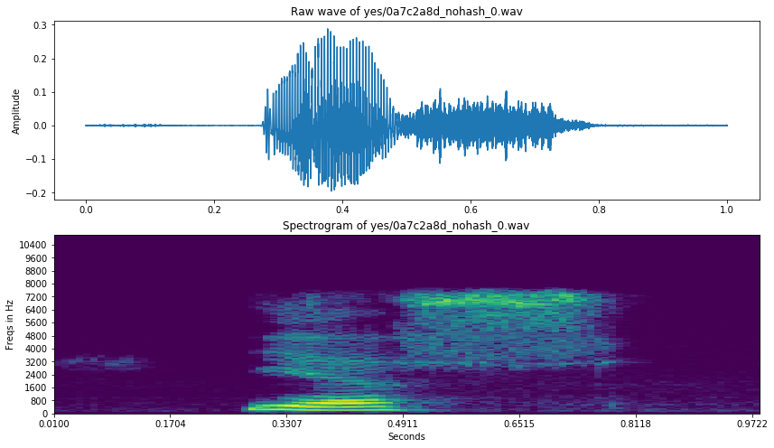

```python
freqs, times, spectrogram = log_specgram(samples, sample_rate)

fig = plt.figure(figsize=(14, 8))
ax1 = fig.add_subplot(211)
ax1.set_title('Raw wave of ' + filename)
ax1.set_ylabel('Amplitude')
ax1.plot(np.linspace(0, sample_rate/len(samples), sample_rate), samples)

ax2 = fig.add_subplot(212)
ax2.imshow(spectrogram.T, aspect='auto', origin='lower',
           extent=[times.min(), times.max(), freqs.min(), freqs.max()])
ax2.set_yticks(freqs[::16])
ax2.set_xticks(times[::16])
ax2.set_title('Spectrogram of ' + filename)
ax2.set_ylabel('Freqs in Hz')
ax2.set_xlabel('Seconds')
```

If we use spectrogram as an input features for Neural Network, we have to remember to normalize features. We would need to normalize all spectra in the dataset. We would use functions in the follwoing cell, but not just for one spectrum, but rather all.

```python
# Do not run this code
mean = np.mean(spectrogram, axis=0)
std = np.std(spectrogram, axis=0)
spectrogram = (spectrogram - mean) / std
```

### Librosa, Pyhton Sound Processing Library¶

It appears that `librosa` is the most popular sound processing library. To have Librosa work properly on Windows, you need to have package `ffmpeg` installed and its `ffmpeg/bin` directory placed in the `PATH` environmental variable. Install librosa version 0.6.3. At least this code has some issues with the newest version of that library.

```python
# To load audio files and resample a signal at 16000Hz, you would use command like:
#librosa.load(audio_path, sr=16000)
# To load files without resampling, do:
#librosa.load(audio_path, sr=None)
```

### Fourier Transformation & Mel-Frequency Spectrum

**Fourier Transform:**

[figure not shown]

The first processing step is the computation of the frequency domain representation of the input signal. This is achieved by computing the **Discrete Fourier Transform.**  
Where N is the number of sampling points within a speech frame and the time frame τ. For implementations the Fast Fourier Transform, which is a variation of the Discrete Fourier Transformation optimized for speed, is used.

**Mel-Frequency Spectrum (MFC):**

The second processing step is the computation of the mel-frequency spectrum.  
This processing step can be described by d the amplitude of the band-pass filter with the index j at the frequency k and the power of each frequency band is computed with Nd different "band-pass filters". This filtering mimics the human ear because the **human auditory system uses the power over a frequency band as signal for further processing.**

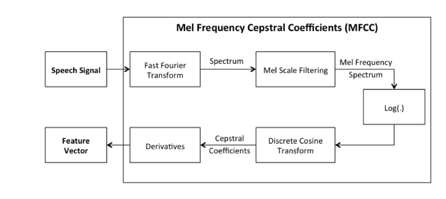

```python
from IPython.display import Image
Image("images/MFCC_Flowchart.png")
```

## Resampled Sound

We could feed these numbers right into a neural network. But trying to recognize speech patterns by processing these samples directly is difficult. Instead, we can make the problem easier by doing some pre-processing on the audio data.  
Let’s start by grouping our sampled audio into 20-millisecond-long chunks. Here’s our first 20 milliseconds of audio (i.e., our first 400 samples): Plotting those numbers as a simple line graph gives us a rough approximation of the original sound wave for that 20 millisecond period of time. This recording is only 1/50th of a second long. But even this short recording is a complex mish-mash of different frequencies of sound. There’s some low sounds, some mid-range sounds, and even some high-pitched sounds sprinkled in. But taken all together, these different frequencies mix together to make up the complex sound of human speech.

To make this data easier for a neural network to process, we are going to break apart this complex sound wave into it’s component parts. We’ll break out the low-pitched parts, the next-lowest-pitched-parts, and so on. Then by adding up how much energy is in each of those frequency bands (from low to high), we create a fingerprint of sorts for this audio snippet.

We do this using a mathematic operation called a **Fourier transform**. It breaks apart the complex sound wave into the simple sound waves that make it up. Once we have those individual sound waves, we add up how much energy is contained in each one.

The end result is a score of how important each frequency range is, from low pitch (i.e. bass notes) to high pitch. Each number below represents how much energy was in each 50hz band of our 20 millisecond audio clip. But this is a lot easier to see when you draw this as a chart. If we repeat this process on every 20 millisecond chunk of audio, we end up with a spectrogram (each column from left-to-right is one 20ms chunk).

### Mel-Frequency Cepstrum Coefficients¶

Features we will extract from sound waves are Mel-Frequency Cepstrum Coefficients (MFCC)

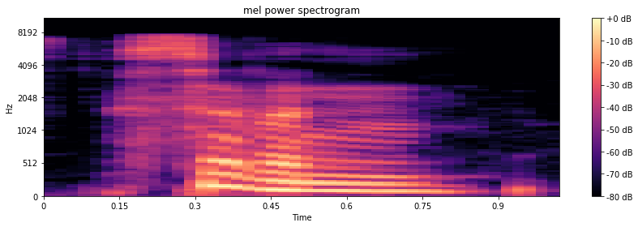

```python
audio_path = './data/seven/6c968bd9_nohash_0.wav'
y, sr = librosa.load(audio_path)
# Let's make and display a mel-scaled power (energy-squared) spectrogram
S = librosa.feature.melspectrogram(y, sr=sr, n_mels=128)
# Convert to log scale (dB). We'll use the peak power (max) as reference.
log_S = librosa.power_to_db(S, ref=np.max)

# Make a new figure
plt.figure(figsize=(12,4))

# Display the spectrogram on a mel scale
# sample rate and hop length parameters are used to render the time axis
librosa.display.specshow(log_S, sr=sr, x_axis='time', y_axis='mel')

# Put a descriptive title on the plot
plt.title('mel power spectrogram')

# draw a color bar
plt.colorbar(format='%+02.0f dB')

# Make the figure layout compact
plt.tight_layout()
```

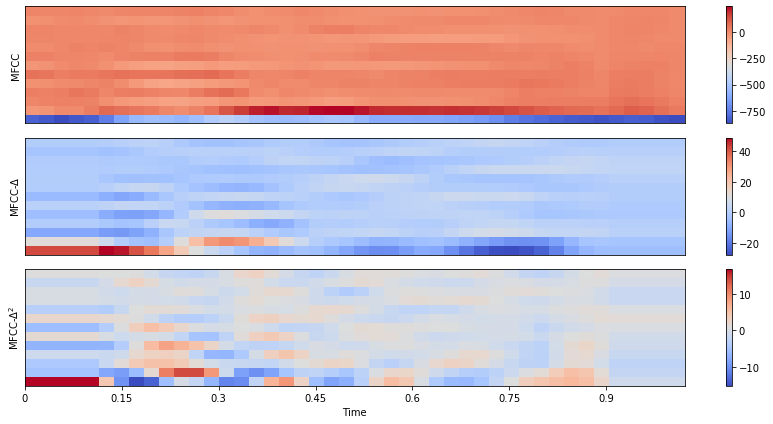

```python
# Next, we'll extract the top 13 Mel-frequency cepstral coefficients (MFCCs)
mfcc        = librosa.feature.mfcc(S=log_S, n_mfcc=13)

# Let's pad on the first and second deltas while we're at it
delta_mfcc  = librosa.feature.delta(mfcc)
delta2_mfcc = librosa.feature.delta(mfcc, order=2)

# How do they look?  We'll show each in its own subplot
plt.figure(figsize=(12, 6))

plt.subplot(3,1,1)
librosa.display.specshow(mfcc)
plt.ylabel('MFCC')
plt.colorbar()

plt.subplot(3,1,2)
librosa.display.specshow(delta_mfcc)
plt.ylabel('MFCC-$\Delta$')
plt.colorbar()

plt.subplot(3,1,3)
librosa.display.specshow(delta2_mfcc, sr=sr, x_axis='time')
plt.ylabel('MFCC-$\Delta^2$')
plt.colorbar()

plt.tight_layout()

# For future use, we'll stack these together into one matrix
M = np.vstack([mfcc, delta_mfcc, delta2_mfcc])
```

In classical, but still important speach recognition systems, as well as in Deep Learning Speech Recognition systems, *MFCC* or similar features are taken as the input to the speech recognition systems instead of spectrograms.

However, in end-to-end (neural-network based) systems, the most common input features are probably raw spectrograms, or mel power spectrograms. For example *MFCC* decorrelates features, but NNs deal with correlated features well. Also, if you understand mel filters, you may consider their sensible usage.

## Silence removal

Let's listen to that `yes` file

```python
ipd.Audio(samples, rate=sample_rate)
```

[interactive chart not shown]

Some VAD (Voice Activity Detection) will be really useful here. Although the words are short, there is a lot of silence in them. A decent VAD could reduce training size a lot, accelerating training speed significantly. Let's cut a bit of the file from the beginning and from the end and listen to it again (based on a plot above, we take samples from 4000 to 9600):

```python
samples_cut = samples[4000:9600]
ipd.Audio(samples_cut, rate=sample_rate)
```

[interactive chart not shown]

We can plot the spectrogram, together with presumed alignment of *'y' 'e' 's'* graphems

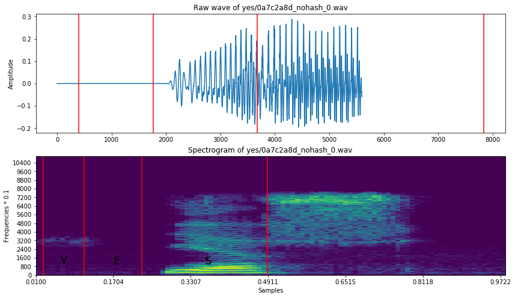

```python
freqs, times, spectrogram_cut = log_specgram(samples, sample_rate)

fig = plt.figure(figsize=(14, 8))
ax1 = fig.add_subplot(211)
ax1.set_title('Raw wave of ' + filename)
ax1.set_ylabel('Amplitude')
ax1.plot(samples_cut)

ax2 = fig.add_subplot(212)
ax2.set_title('Spectrogram of ' + filename)
ax2.set_ylabel('Frequencies * 0.1')
ax2.set_xlabel('Samples')
ax2.imshow(spectrogram_cut.T, aspect='auto', origin='lower',
           extent=[times.min(), times.max(), freqs.min(), freqs.max()])
ax2.set_yticks(freqs[::16])
ax2.set_xticks(times[::16])
ax2.text(0.06, 1000, 'Y', fontsize=18)
ax2.text(0.17, 1000, 'E', fontsize=18)
ax2.text(0.36, 1000, 'S', fontsize=18)

xcoords = [0.025, 0.11, 0.23, 0.49]
for xc in xcoords:
    ax1.axvline(x=xc*16000, c='r')
    ax2.axvline(x=xc, c='r')
```

Please adjust boundaries of sounds for 'Y','E' and 'S' in the above code.

## Resampling - dimensionality reduction

Another way to reduce the dimensionality of our data is to resample recordings.

You can hear that the recording don't sound very natural, because they are sampled with 16k frequency, and we usually hear much more. However, [the most speech related frequencies are presented in smaller band](https://en.wikipedia.org/wiki/Voice_frequency). That's why you can still understand another person talking to the telephone, where GSM signal is sampled to 8000 Hz.

Summarizing, we could resample our dataset to 8k. We will discard some information that shouldn't be important, and we'll reduce size of the data.

We have to remember that it can be risky, because sometimes very small difference in sound matter, so we don't want to lost anything. On the other hand, first experiments can be done much faster with smaller training size.

We'll need to calculate FFT (Fast Fourier Transform). Definition:

```python
def custom_fft(y, fs):
    T = 1.0 / fs
    N = y.shape[0]
    yf = fft(y)
    xf = np.linspace(0.0, 1.0/(2.0*T), N//2)
    vals = 2.0/N * np.abs(yf[0:N//2])  # FFT is simmetrical, so we take just the first half
    # FFT is also complex, to we take just the real part (abs)
    return xf, vals
```

Let's read some recording, resample it, and listen. We can also compare FFT-s. Notice, that there is almost no information above 4000 Hz in the original signal.

```python
audio_path='./data'
filename = '/happy/0b09edd3_nohash_0.wav'
new_sample_rate = 16000

samples, sample_rate = librosa.load(str(audio_path) + filename)
resampled = signal.resample(samples, int(new_sample_rate/sample_rate * samples.shape[0]))
```

```python
ipd.Audio(samples, rate=sample_rate)
```

[interactive chart not shown]

```python
ipd.Audio(resampled, rate=new_sample_rate)
```

[interactive chart not shown]

There is almost no difference!

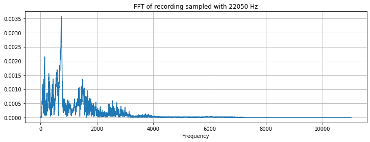

```python
xf, vals = custom_fft(samples, sample_rate)
plt.figure(figsize=(12, 4))
plt.title('FFT of recording sampled with ' + str(sample_rate) + ' Hz')
plt.plot(xf, vals)
plt.xlabel('Frequency')
plt.grid()
plt.show()
```

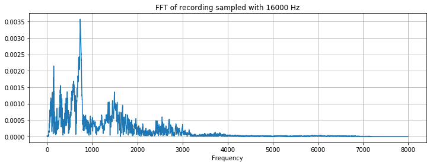

```python
xf, vals = custom_fft(resampled, new_sample_rate)
plt.figure(figsize=(12, 4))
plt.title('FFT of recording sampled with ' + str(new_sample_rate) + ' Hz')
plt.plot(xf, vals)
plt.xlabel('Frequency')
plt.grid()
plt.show()
```

## Features extraction steps

We will use the following feature extraction algorithm :

1. Resampling to reduce the volume of data
2. *VAD (Voice Activated Detection)* for elimination or padding of portion of files without speech.
3. Maybe padding with 0 to make all signals have equal length
4. Determine Log spectrogram (or *MFCC*, or *PLP*)
5. Features normalization with *mean* and *std*
6. Stacking of a given number of frames to get temporal information

*Perceptual Linear Prediction (PLP)* Motivated by hearing perception, it uses equal loudness pre-emphasis and cube-root compression instead of the log compression. It also uses linear regressive to finalize the cepstral coefficients. PLP has slightly better accuracy and slightly better noise robustness.

## Dataset examination

Before we proceed with extraction of features with need to perform standard investgation of the dataset.

### Identify the Number of Labels, Numbers of Samples under each label, etc.

```python
audio_path= './data'
dirs = [f for f in os.listdir(audio_path) if isdir(join(audio_path,f))]
dirs.sort()
print('Number of labels: ' + str(len(dirs)))
```

```
Number of labels: 35
```

### Histogram with number of samples in every class (label)

```python
"""
HW Assignment"""
number_of_recordings = []
for direct in dirs:
    waves = [f for f in os.listdir(join(audio_path, direct)) if f.endswith('.wav')]
    number_of_recordings.append(len(waves))

data = [go.Histogram(x=dirs, y=number_of_recordings)]
trace = go.Bar(
    x=dirs,
    y=number_of_recordings,
    marker=dict(color = number_of_recordings, colorscale=[[0, 'green'], [0.5, 'red'], [1.0, 'rgb(0, 0, 255)']], showscale=True
    ),
)
layout = go.Layout(
    title='Number of recordings in given label',
    xaxis = dict(title='Words'),
    yaxis = dict(title='Number of recordings')
)
py.iplot(go.Figure(data=[trace], layout=layout))
""""""
```

[interactive chart not shown]

```
''
```

Dataset is not uniform but is balanced. There are no words (labels) with number of samples orders of magnitude smaller than in other classes.

### Deeper Analysis of the Recordings

Recordings come from very different sources. Some of them can come from mobile GSM channel.

*It is extremely important to split the dataset in a way that one speaker doesn't occur in both train and test sets.*

We will actually not perform such separation here. We do not have enough meta data and spektral analysis for classiffication of sounds by speakers is longer than we can tolerate in this set of examples.

```
seven/caf1803e_nohash_0.wav
data/
data/seven/caf1803e_nohash_0.wav
```

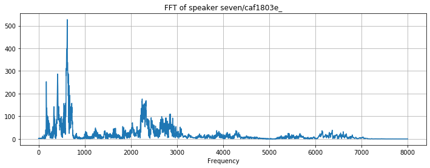

```
seven/0b77ee66_nohash_1.wav
data/
data/seven/0b77ee66_nohash_1.wav
```

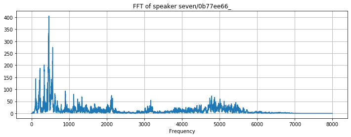

```python
audio_path="data/"
# filenames = ['/on/004ae714_nohash_1.wav','/on/0137b3f4_nohash_1.wav']
filenames = ['seven/caf1803e_nohash_0.wav','seven/0b77ee66_nohash_1.wav']
for filename in filenames:
    print(filename)
    print(audio_path)
    print(join(audio_path,filename))
    sample_rate, samples = wavfile.read(join(audio_path, filename))
    xf, vals = custom_fft(samples, sample_rate)
    plt.figure(figsize=(12, 4))
    plt.title('FFT of speaker ' + filename[0:15])
    plt.plot(xf, vals)
    plt.xlabel('Frequency')
    plt.grid()
    plt.show()
```

It is even better to listen to the sound.

```python
print('Speaker ' + filenames[0][0:15])
ipd.Audio(str(audio_path)+filenames[0])
ipd.Audio(samples, rate=sample_rate)
```

```
Speaker seven/caf1803e_
```

[interactive chart not shown]

```python
ipd.Audio(samples, rate=sample_rate)
```

[interactive chart not shown]

The next one comes from a different speaker.

```python
print('Speaker ' + filenames[0][0:15])
#ipd.Audio(join(train_audio_path, filenames[1]))
print('seven/d21fd169_nohash_1.wav')
ipd.Audio(join(audio_path, 'seven/d21fd169_nohash_1.wav'))
```

```
Speaker seven/caf1803e_
seven/d21fd169_nohash_1.wav
```

[interactive chart not shown]

### Removal of Silence

There are also recordings with noticeable silence. Silence in captured recording is an oportunity for some compression?

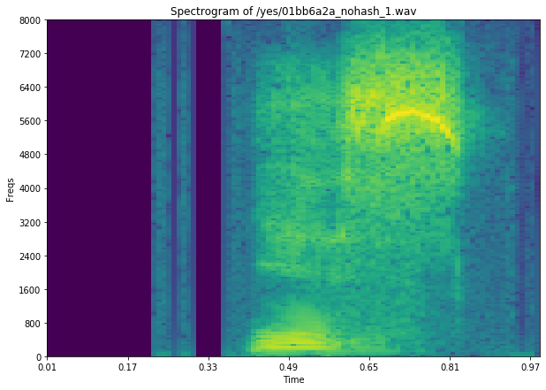

```python
filename = '/yes/01bb6a2a_nohash_1.wav'
sample_rate, samples = wavfile.read(str(audio_path) + filename)
freqs, times, spectrogram = log_specgram(samples, sample_rate)

plt.figure(figsize=(10, 7))
plt.title('Spectrogram of ' + filename)
plt.ylabel('Freqs')
plt.xlabel('Time')
plt.imshow(spectrogram.T, aspect='auto', origin='lower',
           extent=[times.min(), times.max(), freqs.min(), freqs.max()])
plt.yticks(freqs[::16])
plt.xticks(times[::16])
plt.show()
```

Dark blue regions represent silence, i.e. absence of useful signal.

### Determine lengths of recordings

As an illustration we will find all the files that have 1 second duration:

```python
print(dirs)
print(audio_path)
```

```
['backward', 'bed', 'bird', 'cat', 'dog', 'down', 'eight', 'five', 'follow', 'forward', 'four', 'go', 'happy', 'house', 'learn', 'left', 'marvin', 'nine', 'no', 'off', 'on', 'one', 'right', 'seven', 'sheila', 'six', 'stop', 'three', 'tree', 'two', 'up', 'visual', 'wow', 'yes', 'zero']
data/
```

```python
num_of_shorter = 0
print(audio_path)
for direct in dirs:
    waves = [f for f in os.listdir(str(audio_path)+ direct) if f.endswith('.wav')]
    for wav in waves:
        sample_rate, samples = wavfile.read(str(audio_path) +direct + '/' + wav)
        if samples.shape[0] < sample_rate:
            num_of_shorter += 1
print('Number of recordings shorter than 1 second: ' + str(num_of_shorter))
```

```
data/
Number of recordings shorter than 1 second: 10435
```

To bring those short files up to the standard length, we can pad them with zeros. Our Deep Learnign techniques usually prefer if we feed them inputs of uniform size.

### Mean Spectrograms and FFT

Let us plot mean FFT for several words. We will select words: 'yes', 'bed', 'cat', 'happy' & 'seven'

```
['bed', 'cat', 'happy', 'seven', 'yes']
```

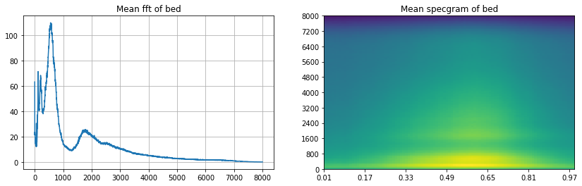

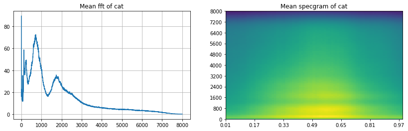

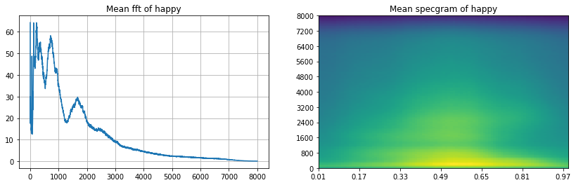

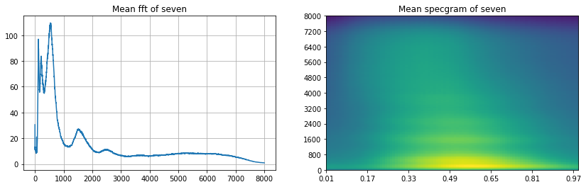

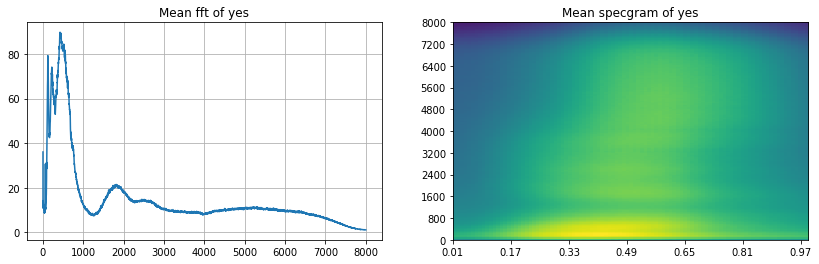

```python
to_keep = 'yes bed cat happy seven'.split()
dirs = [d for d in dirs if d in to_keep]

print(dirs)

for direct in dirs:
    vals_all = []
    spec_all = []

    waves = [f for f in os.listdir(join(audio_path, direct)) if f.endswith('.wav')]
    for wav in waves:
        sample_rate, samples = wavfile.read(audio_path + '/'+ direct + '/' + wav)
        if samples.shape[0] != 16000:
            continue
        xf, vals = custom_fft(samples, 16000)
        vals_all.append(vals)
        freqs, times, spec = log_specgram(samples, 16000)
        spec_all.append(spec)

    plt.figure(figsize=(14, 4))
    plt.subplot(121)
    plt.title('Mean fft of ' + direct)
    plt.plot(np.mean(np.array(vals_all), axis=0))
    plt.grid()
    plt.subplot(122)
    plt.title('Mean specgram of ' + direct)
    plt.imshow(np.mean(np.array(spec_all), axis=0).T, aspect='auto', origin='lower',
               extent=[times.min(), times.max(), freqs.min(), freqs.max()])
    plt.yticks(freqs[::16])
    plt.xticks(times[::16])
    plt.show()
```

## Gaussian Mixtures modeling

We could use simple GMMs for words to check what can we model and how hard it is to distinguish the words. We can use [Scikit-learn](http://scikit-learn.org/) for that, however it is not straightforward and lasts very long here, so I abandon this idea for now.

## Frequency components across the words

One popular type of plots that depicts the frequency content of different words is called violin plot.

```python
def violinplot_frequency(dirs, freq_ind):
    """ Plot violinplots for given words (waves in dirs) and frequency freq_ind
    from all frequencies freqs."""

    spec_all = []  # Contain spectrograms
    ind = 0
    for direct in dirs:
        spec_all.append([])

        waves = [f for f in os.listdir(join(audio_path, direct)) if
                 f.endswith('.wav')]
        for wav in waves[:100]:
            sample_rate, samples = wavfile.read(
                audio_path +'/'+ direct + '/' + wav)
            freqs, times, spec = log_specgram(samples, sample_rate)
            spec_all[ind].extend(spec[:, freq_ind])
        ind += 1

    # Different lengths = different num of frames. Make number equal
    minimum = min([len(spec) for spec in spec_all])
    spec_all = np.array([spec[:minimum] for spec in spec_all])

    plt.figure(figsize=(13,7))
    plt.title('Frequency ' + str(freqs[freq_ind]) + ' Hz')
    plt.ylabel('Amount of frequency in a word')
    plt.xlabel('Words')
    sns.violinplot(data=pd.DataFrame(spec_all.T, columns=dirs))
    plt.show()
```

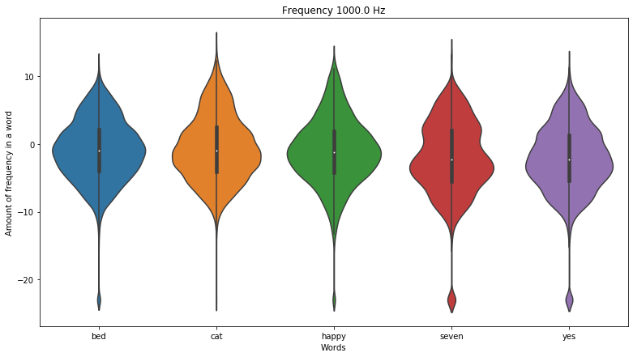

```python
violinplot_frequency(dirs, 20)
```

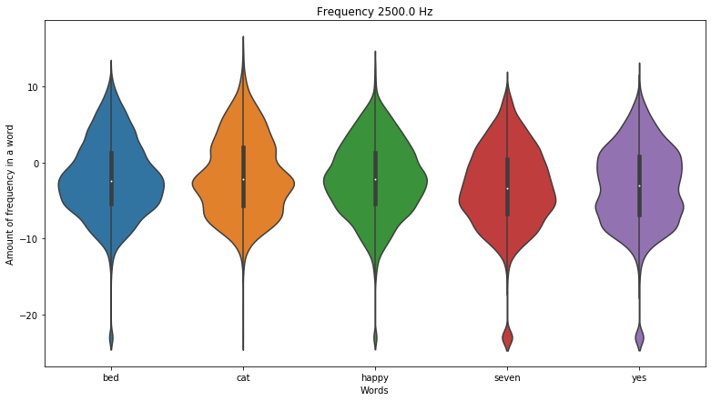

```python
violinplot_frequency(dirs, 50)
```

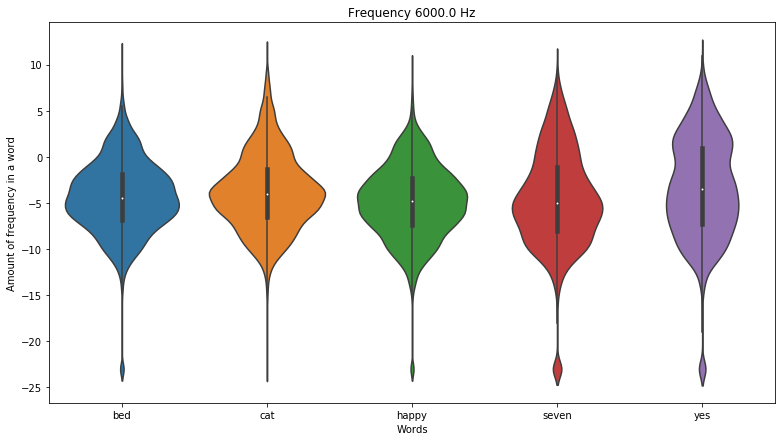

```python
violinplot_frequency(dirs, 120)
```

### Anomaly detection

We should check if there are any recordings that somehow stand out from the rest. We can project our entire dataset to a space of lower dimensionality (2 or 3) and interactively check for any anomaly. We will use PCA for dimensionality reduction.

Please note that the following cell takes long time to run. To reduce run time, we reduced the number of words in `./data` directory to six: `bed`, `bird`, `cat`, `five`, `happy` and `seven`

```python
audio_path= './data'
dirs = [f for f in os.listdir(audio_path) if isdir(join(audio_path,f))]
dirs.sort()
print('Number of labels: ' + str(len(dirs)))
```

```
Number of labels: 6
```

```python
fft_all = []
names = []
for direct in dirs:
    waves = [f for f in os.listdir(str(audio_path) +'/'+ direct) if f.endswith('.wav')]
    for wav in waves:
        samples, sample_rate = librosa.load(audio_path +'/'+ direct + '/' + wav)
        if samples.shape[0] != sample_rate:
            samples = np.append(samples, np.zeros((sample_rate - samples.shape[0], )))
        x, val = custom_fft(samples, sample_rate)
        fft_all.append(val)
        names.append(direct + '/' + wav)

fft_all = np.array(fft_all)

# Normalization
fft_all = (fft_all - np.mean(fft_all, axis=0)) / np.std(fft_all, axis=0)

# Dim reduction
pca = PCA(n_components=3)
fft_all = pca.fit_transform(fft_all)

def interactive_3d_plot(data, names):
    scatt = go.Scatter3d(x=data[:, 0], y=data[:, 1], z=data[:, 2], mode='markers', text=names)
    data = go.Data([scatt])
    layout = go.Layout(title="Anomaly detection")
    figure = go.Figure(data=data, layout=layout)
    py.iplot(figure)

interactive_3d_plot(fft_all, names)
```

[interactive chart not shown]

```python
print('Recording of happy/abbfc3b4_nohash_1.wav')
ipd.Audio(audio_path +'/'+ 'happy/abbfc3b4_nohash_1.wav')
```

[output not shown]

```python
print('Recording yes/e4b02540_nohash_0.wav')
ipd.Audio(join(audio_path +'/'+ 'yes/e4b02540_nohash_0.wav'))
```

[output not shown]

If you are looking for anomalies for individual words, you could, for example, find this file for word seven:

```python
print('Recording seven/b1114e4f_nohash_0.wav')
ipd.Audio(audio_path +'/'+ 'seven/b1114e4f_nohash_0.wav')
```

```
Recording seven/b1114e4f_nohash_0.wav
```

[interactive chart not shown]

The first two samples contained nothing obviously important. The third sample did sound weird. Usually, you can find some distortions using this method.

## Where to look for the inspiration

**Speech recognition is a really big R&D field and it is hard to get to know important things in short time!**

You can take many different approaches for solutions based on neural networks and architectures. Connectionist Temporal Classification (CTC) by using Recurrent Neural Network (RNN) in TensorFlow, Keras, Automatic Speech Recognition (ASR), Hidden Markov Model (HMM) based on ASR, Gaussian mixture models with HMMs, Deep models with HMMs, Large Vocabulary Continuous Speech Recognition Systems (LVCSR).

This tutorial focuses on two models and a very small vocabulary, with recordings with only one word in it, with a (mostly) given length:

1. Encoder-decoder: https://arxiv.org/abs/1508.01211
2. RNNs with CTC loss: https://arxiv.org/abs/1412.5567
3. Classic speech recognition is described here: http://www.ece.ucsb.edu/Faculty/Rabiner/ece259/Reprints/tutorial%20on%20hmm%20and%20applications.pdf

You can find *Kaldi* [Tutorial for dummies](http://kaldi-asr.org/doc/kaldi_for_dummies.html), with a problem similar to this competition in some way.

Notebook code was adapted from the follwing sources:  
Tensorflow:  
https://www.tensorflow.org/tutorials/audio_recognition https://github.com/ugnelis/tensorflow-rnn-ctc/blob/master/README.md  
LibROSA:https://github.com/librosa/librosa/blob/master/examples/LibROSA%20demo.ipynb  
Kaggle / Data / Python code:  
https://github.com/pannous/tensorflow-speech-recognition https://www.kaggle.com/davids1992/speech-representation-and-data-exploration/notebook https://www.kaggle.com/c/tensorflow-speech-recognition-challenge/download/train.7z https://www.kaggle.com/c/tensorflow-speech-recognition-challenge/download/test.7z

### Sampled Sound Data Processing

We now know how to generate an array of numbers which represent the sound wave’s amplitude at 1/16.000 of a second intervals.

We could feed these numbers right into a neural network. But trying to recognize speech patterns by processing these samples directly is difficult. Instead, we can make the problem easier by doing some pre-processing on the audio data. Let’s start by grouping our sampled audio into 20-millisecond-long chunks. Here’s our first 20 milliseconds of audio (i.e., our first 400 samples): Plotting those numbers as a simple line graph gives us a rough approximation of the original sound wave for that 20 millisecond period of time. This recording is only 1/50th of a second long. But even this short recording is a complex mish-mash of different frequencies of sound. There’s some low sounds, some mid-range sounds, and even some high-pitched sounds sprinkled in. But taken all together, these different frequencies mix together to make up the complex sound of human speech.

To make this data easier for a neural network to process, we are going to break apart this complex sound wave into it’s component parts. We’ll break out the low-pitched parts, the next-lowest-pitched-parts, and so on. Then by adding up how much energy is in each of those frequency bands (from low to high), we create a fingerprint of sorts for this audio snippet.

We do this using a mathematic operation called a Fourier transform. It breaks apart the complex sound wave into the simple sound waves that make it up. Once we have those individual sound waves, we add up how much energy is contained in each one.

The end result is a score of how important each frequency range is, from low pitch (i.e. bass notes) to high pitch. Each number below represents how much energy was in each 50hz band of our 20 millisecond audio clip. But this is a lot easier to see when you draw this as a chart. If we repeat this process on every 20 millisecond chunk of audio, we end up with a spectrogram (each column from left-to-right is one 20ms chunk).

### Simple Speech Recognition Demo

Code used in the example below is borrowed from this blog: https://blog.manash.me/building-a-dead-simple-word-recognition-engine-using-convnet-in-keras-25e72c19c12b . Processing in this portion of the notebook depends on the Python script preprocess.py. File preprocess.py is provide on the class site, week 12 folder.

### Build Model - Keras Embedding, Vectors

We need to prepare a fixed size vector for each audio file for classification. TensorFlow guide contains a very good guide on embedding. Embedding is a mapping from discrete objects, such as words, to vectors of real numbers. https://www.tensorflow.org/programmers_guide/embedding. We are dealing with a specific domain, audio embedding. What technique we should actually use to embed the audio into vector space? **MFCC encoding** We then compute MFCC using **librosa** library.

MFCC vectors might vary in size for different audio input, remember CNNs can’t handle sequence data so we need to prepare a fixed size vector for all of the audio files. To overcome this problem all we need to do is to pad the output vectors with constant value such as "zero"  
For each audio file the vector is a 20 by 11 dimensional matrix. When we embed things, everything gets converted into vector (We can treat it just like an image). we need to reshape it to give a depth. we need to encode this output vector into one-hot-encoded one to perform softmax (keras has a built in function)

```python
!pip install ffmpeg
```

### Package FFMPEG

FFmpeg is the leading multimedia framework, able to decode, encode, transcode, mux, demux, stream, filter and play pretty much any format that humans and machines have created. FFmpeg supports the most obscure ancient formats and the most modern, cutting edge, multimedia format. Librosa aparently depends on FFmpeg.

Both on the command prompt and in a Jupyter cell install ffmpeg using pip, e.g.  
`!pip install ffmpeg`  
The above might not be enough.  
From `https://ffmpeg.zeranoe.com/builds/` download `ffmpeg-20190426-f857753-win64-static.zip` or similarely named file and expand it in one of program directories, for example `C:\Program File\ffmpeg`. Add directory `C:\Program Files\ffmpeg\bin` (or whatever `ffmpeg/bin` directory you have) to your envariomental variable `PATH`. On Mac OS, your PATH woud read differently. On Ubuntu your directory is most probaly `/usr/bin/ffmepg`. Verify by typing `which ffmpeg` at the Linux prompt.

### Version of librosa package

Code below requires older version of libroasa package. Please downgrade librosa to the version 0.6.3

```python
!pip install --upgrade librosa==0.6.3
```

You need to run this cell once, transform Wav files into MFCC- and export transformed values into *.npy files. Training of the model with different words does nto require new set of* .npy files.

```python
%load_ext autoreload
#%autoreload 2
import tensorflow as tf
from preprocess import *
from tensorflow import keras
from tensorflow.keras.models import Sequential
from tensorflow.keras.layers import Dense, Dropout, Flatten, Conv2D, MaxPooling2D
from tensorflow.keras.utils import to_categorical
from scipy.io import wavfile
import IPython.display as ipd

# Second dimension of the feature is dim2
feature_dim_2 = 11
path = './data'
# Save data to array file first
save_data_to_array(max_len=feature_dim_2)
```

### Loading train set and test set

The routine bellow looks into the `./data` directory and select for loading those *.npy files which have corresponding directory (word) in `./data` directory. `/data` directory could contain empty subdirectories named after selected words.

```python
X_train, X_test, y_train, y_test = get_train_test()

# # Feature dimension
feature_dim_1 = 20
channel = 1
epochs = 1000
batch_size = 100
verbose = 1
num_classes = 6   # number of words used for training.

# Reshaping to perform 2D convolution
X_train = X_train.reshape(X_train.shape[0], feature_dim_1, feature_dim_2, channel)
X_test = X_test.reshape(X_test.shape[0], feature_dim_1, feature_dim_2, channel)

y_train_hot = to_categorical(y_train)
y_test_hot = to_categorical(y_test)
```

```python
print(X_train.shape, X_test.shape)
print(y_train.shape,y_test.shape)
```

```
(9727, 20, 11, 1) (6486, 20, 11, 1)
(9727,) (6486,)
```

### Define the Model

CNN & Rectified Linear Units, Conv2D reduced into a single vector of class scores(ConvNet have neurons arranged in 3 dimensions: width, height, depth)

We will use rectified linear units **(ReLUs)** for the hidden layers. A rectified linear unit has output 0 if the input is less than 0, and raw output otherwise. That is, if the input is greater than 0, the output is equal to the input. ReLUs' machinery is more like a real neuron in your body.  
**ReLU activations** are the simplest non-linear activation function you can use. When you get the input is positive, the derivative is just 1, so there isn't the squeezing effect you meet on backpropagated errors from the sigmoid function. Research has shown that ReLUs result in much faster training for large networks.

```python
def get_model():
    model = Sequential()
    model.add(Conv2D(32, kernel_size=(2, 2), activation='relu', input_shape=(feature_dim_1, feature_dim_2, channel)))
    model.add(Conv2D(48, kernel_size=(2, 2), activation='relu'))
    model.add(Conv2D(120, kernel_size=(2, 2), activation='relu'))
    model.add(MaxPooling2D(pool_size=(2, 2)))
    model.add(Dropout(0.25))
    model.add(Flatten())
    model.add(Dense(128, activation='relu'))
    model.add(Dropout(0.25))
    model.add(Dense(64, activation='relu'))
    model.add(Dropout(0.4))
    model.add(Dense(num_classes, activation='softmax'))
    model.compile(loss=keras.losses.categorical_crossentropy,
                  optimizer=keras.optimizers.Adadelta(),
                  metrics=['accuracy'])
    return model

# Predicts one sample
def predict(filepath, model):
    sample = wav2mfcc(filepath)
    sample_reshaped = sample.reshape(1, feature_dim_1, feature_dim_2, channel)
    return get_labels()[0][
            np.argmax(model.predict(sample_reshaped))
    ]
```

### Train the Model

```python
model = get_model()
# model.fit(X_train, y_train_hot, batch_size=batch_size, epochs=epochs, verbose=verbose, validation_data=(X_test, y_test_hot))
hist = model.fit(X_train, y_train_hot, batch_size=batch_size, epochs=epochs, verbose=verbose, validation_data=(X_test, y_test_hot))
```

```
Train on 9727 samples, validate on 6486 samples
```

```python
hist.history.keys()
```

```
dict_keys(['loss', 'accuracy', 'val_loss', 'val_accuracy'])
```

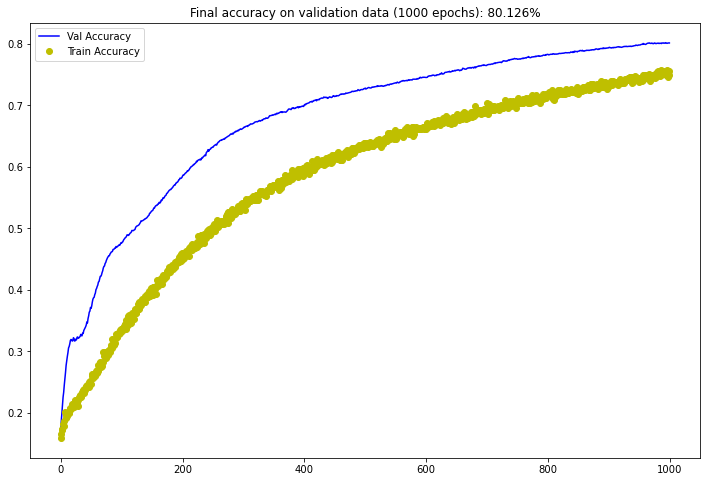

```python
import matplotlib.pyplot as plt
%matplotlib inline

plt.figure(figsize=(12,8))
plt.plot(hist.history['val_accuracy'], 'b-', label='Val Accuracy')
plt.plot(hist.history['accuracy'], 'yo', label='Train Accuracy')
plt.title("Final accuracy on validation data (1000 epochs): {:.3%}".format(hist.history['val_accuracy'][-1:][0]))
plt.legend(loc=2)
_ = plt.show()
```

### Make Prediction

Let us see whether trained network could properly classify sounds for bed, cat, happy. Test with recorded sounds in the test data set.

```python
# `bed` with southern accent
# saved vectors bed, cat, happy
#'/happy/0685264e_nohash_0.wav
# 'd486fb84_nohash_0.wav, happy d486fb84_nohash_1.wav
# cat 6ac35824_nohash_0.wav, 6ac35824_nohash_1.wav
train_audio_path = './data/'
filename = 'bed/004ae714_nohash_1.wav'
new_sample_rate = 16000
samples, sample_rate = librosa.load(str(train_audio_path) + filename)
ipd.Audio(samples, rate=sample_rate)
```

[interactive chart not shown]

```python
print(predict('./data/bed/004ae714_nohash_1.wav', model=model))
```

```
five
```

```python
train_audio_path = './data/'
filename = 'cat/6ac35824_nohash_0.wav'
new_sample_rate = 16000
samples,sample_rate = librosa.load(str(train_audio_path) + filename)
ipd.Audio(samples, rate=sample_rate)
```

[interactive chart not shown]

```python
print(predict('./data/cat/6ac35824_nohash_0.wav', model=model))
```

```
cat
```

```python
train_audio_path = './data/'
filename = 'happy/0685264e_nohash_0.wav'
new_sample_rate = 16000
samples, sample_rate = librosa.load(str(train_audio_path) + filename)
ipd.Audio(samples, rate=sample_rate)
```

[interactive chart not shown]

```python
print(predict('./data/happy/0685264e_nohash_0.wav', model=model))
```

```
happy
```

```python
train_audio_path = './data/'
#filename = 'yes/0a7c2a8d_nohash_0.wav'
filename = 'seven/b1114e4f_nohash_0.wav'
new_sample_rate = 16000
samples, sample_rate = librosa.load(str(train_audio_path) + filename)
ipd.Audio(samples, rate=sample_rate)
```

[interactive chart not shown]

```python
print(predict('./data/seven/b1114e4f_nohash_0.wav', model=model))
```

```
five
```

Some predictions are good and some not so good.